# Proportional, grouped histograms and density plots

Donald T. McKnight (donald.mcknight@my.jcu.edu.au)

# 1 TL:DR

- For grouped histograms where each group sums to 1 (e.g., two species on the same plot):
  - in geom_histogram use: **aes(y=stat(width * density))**
- For grouped histograms where all groups combined sum to 1 (e.g., plotting males and females within a population):
  - in geom_histogram use: **aes(y=..count../sum(..count..))**
- For grouped density plots where each group sums to 1 (e.g., two species on the same plot):
  - in geom_density use: **aes(y=binwidth * ..density..)**
    - binwidth is the binwidth you would use if making a histogram (not the same as bw)
      - binwidth is not a recognized variable name in geom_density. Simply enter it as a number or define it beforehand (e.g., aes(y=2*..density..) for binwidth=2)
- For grouped density plots where all groups combined sum to 1 (e.g., plotting males and females within a population):
  - in geom_density use: **aes(y=binwidth * proportions * ..density..)**
    - binwidth is the binwidth you would use if making a histogram (not the same as bw)
      - binwidth is not a recognized variable name in geom_density. Simply enter it as a number or define it beforehand (e.g., aes(y=2 * proportions * ..density..) for binwidth=2)
    - proportions is the proportion of points belonging to each group
      - this is a vector where each entry is the proportion of points for that group (for each group, the length needs to equal n in geom_density [default is 512])
        - e.g., for two groups consisting of 15 and 5 points (respectively), proportions = c(rep(.75,512),rep(.25,512))
      - I have provided a function (get.props) to make this easy

# 2 Topics covered

- Grouped histograms displayed as proportions
- Grouped density plots (smoothed histograms) displayed as proportions
- Combining histograms and density plots at the same scale (proportions)
- Adding mean lines (across groups) to grouped density plots

# 3 Introduction/the problem

- When making histograms and density plots, we often want the Y axis scaled to represent proportions (or percentages), because this standardizes histograms and curves across groups and puts things on a scale that is intuitive to interpret.
- ggplot (for all its benefits) does not have an intuitive (IMO) method for doing this when you have more than one group, and the solutions that either work for single groups or seem like they should work can give very misleading and inaccurate results.
- Solving this for histograms (via geom_histogram) is fairly easy (though finding the solution online was very difficult), but I was utterly unable to find a solution for density plots (via geom_density), despite finding many others who were struggling with the same issue.
- After much trial and error, I eventually found a solution that seems to work
- This document outlines the issue, presents the code and examples for my solution, and explains why many commonly proposed solutions don’t actually work (but often deceptively look like they work).

**NOTE** I have not done much with these solutions while also using facet_wrap(). I do not know if they will work in that situation (particularly for grouped density plots where all groups collectively sum to 1)

**Disclaimer** I have done my best to test all of this and make sure that it works, but obviously I’m not providing any grantees. Also, there may be more elegant solutions out there, this is just the best that I could come up with.

# 4 Example data

- Load packages
- Make a data frame (“df”) with two groups (“a” and “b”)
- Groups have similarly-shaped distributions, but the median is different and “a” is a bit flatter
- “a” also has twice the sample size of “b”

```r
df <- cbind.data.frame(values = c(75,97,92,95,88,87,89,76,81,83,35,57,52,55,48,37,39,36,50,43,50,57,52,55,48,37,35,36,41,43),id = c(rep("b",10),rep("a",20)))

library(ggplot2) #version 3.3.5
library(dplyr) #version 1.0.8
library(plyr) #version 1.8.6
library(scales) #version 1.1.1 this is only needed to illustrate one of the faulty "solutions"
```

# 5 Histograms

## 5.1 Solutions

### 5.1.1 Grouped histogram where each group sums to 1

- This solution is for cases where you are trying to plot two or more independent groups on the same plot and each group should sum to 1.
- For example, you might use this if “a” and “b” in our example are two species, and the values are the sizes of individuals.
- **Solution:** add aes(y=stat(width*density)) in geom_histogram
- This will calculate the proportions per group
- First I am going to show it using only the strictly necessary code

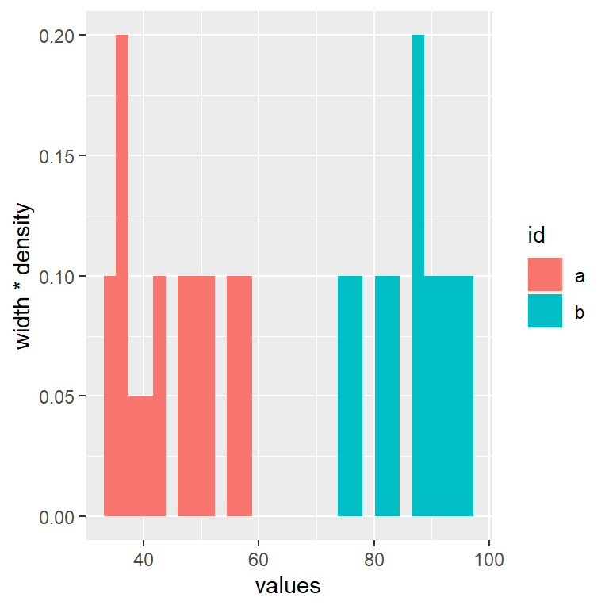

```r
ggplot(df,aes(x=values,fill=id))+
  geom_histogram(aes(y=stat(width*density)))
```

- This worked, but the defaults are pretty awful
- I will add the following arguments and use them throughout
  - binwidth = the width of the bins into which data are grouped
  - boundary = sets the start position of the first bin
  - alpha = sets a transparency
  - color = sets the color of the border around each bar
  - scale_x_continuous = sets the limits on the x axis
  - labs = labels the y axis

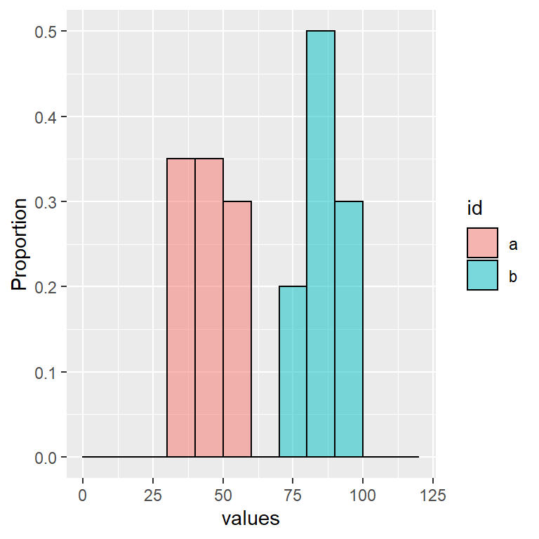

```r
ggplot(df,aes(x=values,fill=id))+
  geom_histogram(binwidth=10,boundary=0,alpha=0.5,color="black",aes(y=stat(width*density)))+
  scale_x_continuous(limits=c(0,120))+
  labs(y="Proportion")
```

- Just to double check, let’s increase the binwidth to 20

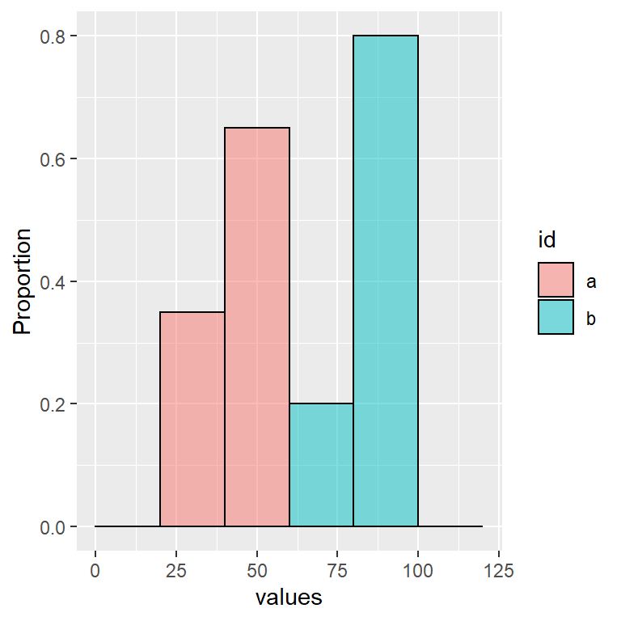

```r
ggplot(df,aes(x=values,fill=id))+
  geom_histogram(binwidth=20,boundary=0,alpha=0.5,color="black",aes(y=stat(width*density)))+
  scale_x_continuous(limits=c(0,120))+
  labs(y="Proportion")
```

- Still works
- For clarity, the sum of each group is now 1 (thus the sum of the entire graph is 2)

#### 5.1.1.1 Why this works

- Briefly, stat(density) and ..density.. are calculating kernel density estimates *not* probabilities. Thus, the integral of the density will always sum to 1, but individual points along the density cloud can be greater than 1.
- To get the probability estimate (which can be treated as a proportion) you need to integrate the values over some length along the x axis.
- This is where width argument comes in, and why multiplying the width by the density gives you a probability (which you can view as a proportion)

### 5.1.2 Grouped histogram where all groups collectively sum to 1

- This solution is for situations where you are plotting related groups, each of which is a proportion of a whole (i.e., the sum of all groups = 1)
  - For example, if our groups “a” and “b” are males and females, and the values are sizes, you might want to look at the distribution of sizes in the entire population while distinguishing males and females
- **Solution:** add aes(y=..count../sum(..count..)) in geom_histogram

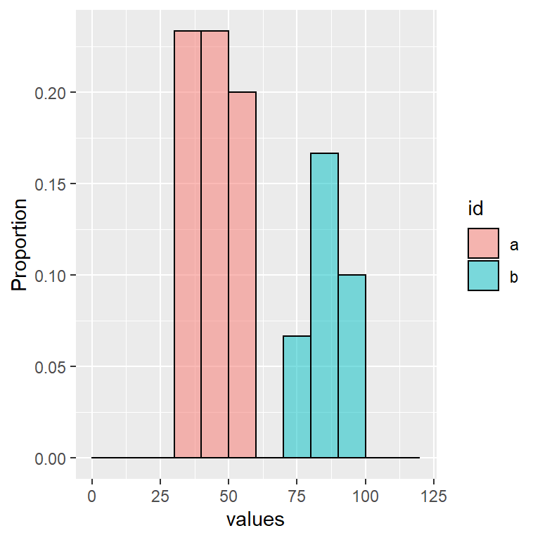

```r
ggplot(df,aes(x=values,fill=id))+
  geom_histogram(binwidth=10,boundary=0,alpha=0.5,color="black",aes(y=..count../sum(..count..)))+
  scale_x_continuous(limits=c(0,120))+
  labs(y="Proportion")
```

- For clarity, the sum of the entire graph is now 1. So the number of data points per group affects the results
- **Note** this will also work if you just have a single group
- **Warning** I saw this solution come up a lot online when people were asking about grouped histograms where *each* group sums to 1 rather than *all* groups collectively summing to 1.
  - This does not work in the former situation (see previous section for how to make that graph)

#### 5.1.2.1 Why this works

```r
p <- ggplot(df,aes(x=values,fill=id))+
  geom_histogram(binwidth=10,boundary=0,alpha=0.5,color="black",aes(y=..count../sum(..count..)))+
  scale_x_continuous(limits=c(0,120))+
  labs(y="Proportion")

ggplot_build(p)$data
```

[output not shown]

[output cut: 36 more lines]

## 5.2 Things that don’t work

### 5.2.1 Default geom_histogram

- Here is the default histogram
- It’s not “wrong,” but it is potentially misleading (depending on the question) because the sample size for “a” is larger than the sample size for “b”
- Also, we want this as proportions

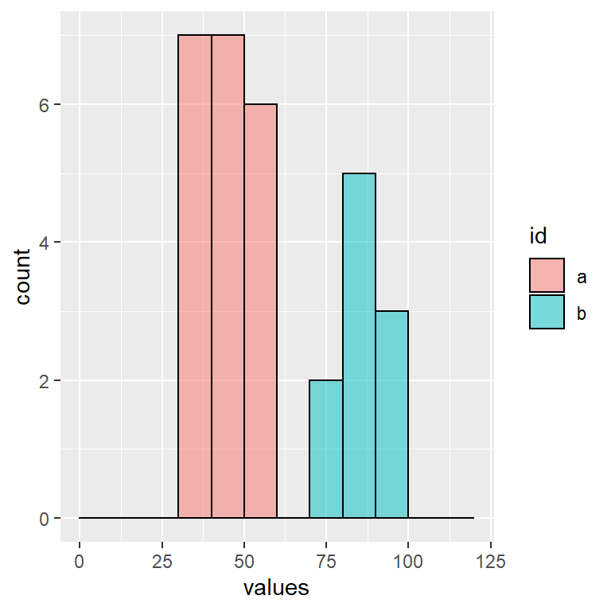

```r
ggplot(df,aes(x=values,fill=id))+
  geom_histogram(binwidth=10,boundary=0,alpha=0.5,color="black")+
  scale_x_continuous(limits=c(0,120))
```

### 5.2.2 scales::percent_format()

- I see this one as a solution very frequently, and it simply does not work (maybe it did in an old version?)
- The solution claims that you simply add one of the following to your code:
  - scale_y_continuous(labels = scales::percent_format())
  - scale_y_continuous(labels = percent, name = “percent”)
- The danger is that it often *looks* like it worked, but if you double check, the numbers are often bogus.
- Using our data, the issue is obvious, but it’s not always this clear

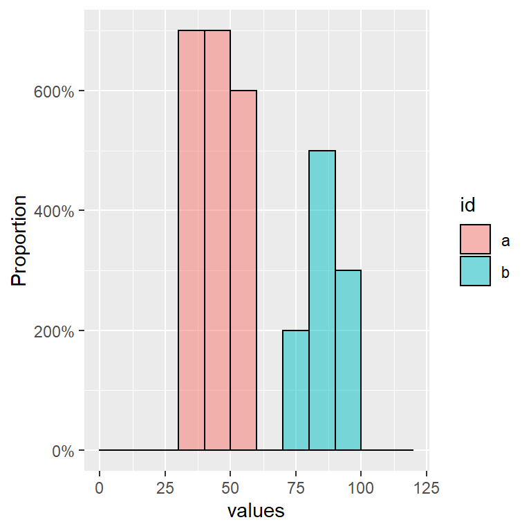

```r
ggplot(df,aes(x=values,fill=id))+
  geom_histogram(binwidth=10,boundary=0,alpha=0.5,color="black")+
  scale_x_continuous(limits=c(0,120))+
  labs(y="Proportion")+
  scale_y_continuous(labels = scales::percent_format())
```

- Obviously, we should not be having bins labeled >100%

### 5.2.3 ..density..

- I have included this one because I have seen it show up as a solution, and while it *sometimes* works, it **does not work in all situations**, but you can mistakenly convince yourself it does work with some dummy data sets
- The issue is that it is making a kernel density estimate histogram, not a simple count histogram. As a result, whether or not the density sums to 1 is entirely dependent on the binwidth and aspects of the data (whereas the integral of the area under the curve will always sum to 1)
- To demonstrate this, let’s divide our data by 10 and run it with a binwidth of 1 and aes(y=..density..)

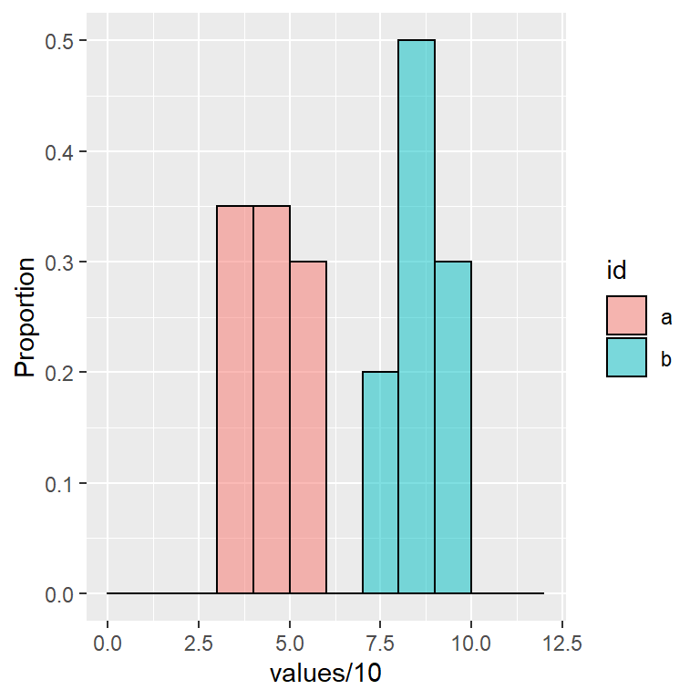

```r
ggplot(df,aes(x=values/10,fill=id))+
  geom_histogram(binwidth=1,boundary=0,alpha=0.5,aes(y=..density..),color="black")+
  scale_x_continuous(limits=c(0,12))+
  labs(y="Proportion")
```

- That *looks* like it worked. All the “a” bars sum to 1, and all the “b” bars sum to 1.
- But watch what happens if we set binwidth to 2 instead of 1

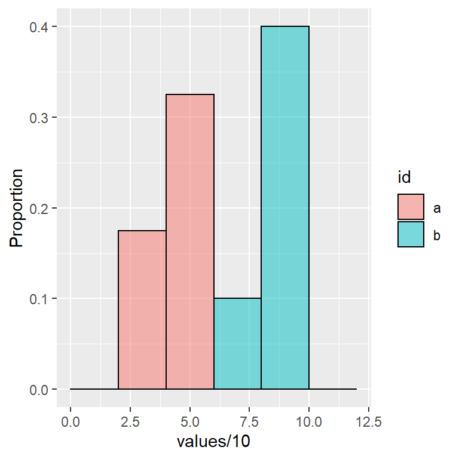

```r
ggplot(df,aes(x=values/10,fill=id))+
  geom_histogram(binwidth=2,boundary=0,alpha=0.5,aes(y=..density..),color="black")+
  scale_x_continuous(limits=c(0,12))+
  labs(y="Proportion")
```

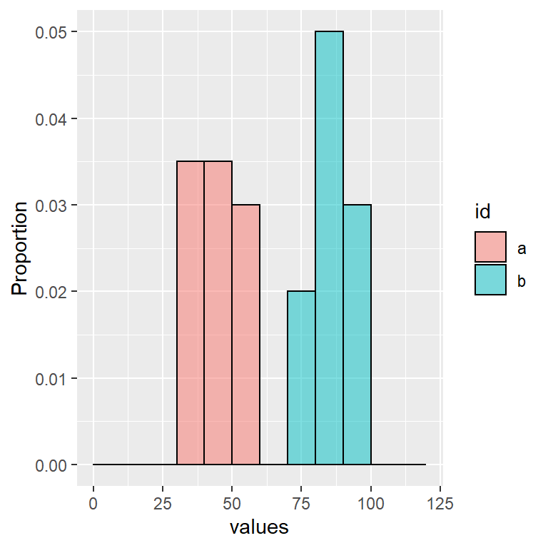

```r
ggplot(df,aes(x=values,fill=id))+
  geom_histogram(binwidth=10,boundary=0,alpha=0.5,aes(y=..density..),color="black")+
  scale_x_continuous(limits=c(0,120))+
  labs(y="Proportion")
```

- So despite being a common answer online, this **does not work** in most cases and should not be used
- This one is particularly dangerous, IMO, because it often *looks* like it worked

# 6 Density plots

- The goal here is fundamentally to make a smoothed histogram. The problem is that geom_density is producing a density estimate *not* a probability
- As with the histograms, we need to integrate using some width (the spread along the x)
- Irritatingly, the trick we used for histograms does not work, but something similar does

## 6.1 Solutions

### 6.1.1 Grouped density plot where each group sums to 1

- This solution is for cases where you are trying to plot two or more independent groups on the same plot and each group should sum to 1.
- For example, you might use this if “a” and “b” in our example are two species, and the values are the sizes of individuals.
- **Solution:** add aes(y=binwidth*..density..) in geom_density
  - binwidth is a number and should be the binwidth you would use if making a histogram (not the same as bw)

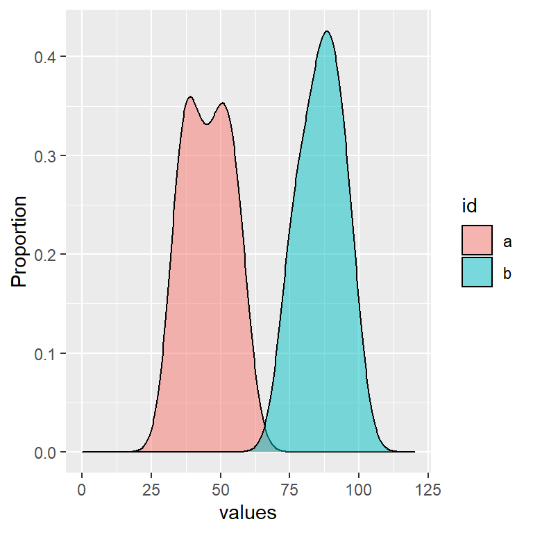

```r
ggplot(df,aes(x=values,fill=id))+
  geom_density(bw=5,alpha=0.5,color="black",aes(y=10*..density..))+
  scale_x_continuous(limits=c(0,120))+
  labs(y="Proportion")
```

- You can prove to yourself that this works by combining it with a histogram (see section 7)

#### 6.1.1.1 Why this works

- If you think back to the histograms, to go from a density to a probability (which we can treat as a proportion), we need to multiply the density by some width value
- Therefore, in geom_density() you can set aes(y=binwidth*..density..) where binwidth is the width of the bins you would want if this was a histogram.
  - **NOTE** binwidth is not an inherent argument in ggplot; it is just a variable name I am using as a placeholder (I am calling it binwidth because it is often best to set this value to the binwidth value you would want in a histogram)
  - binwidth is not inherently the same as the bw argument in geom_density()
  - bw is used internally for geom_density to set the smoothing bandwith
  - leaving bw on default is usually fine, but I personally find that setting it to 1/2 binwidth makes the most sensible graphs

### 6.1.2 Grouped density plot where all groups combined sum to 1

- This solution is for cases where your groups are not independent and are actually a part of some whole, so you want the groups distinguished, but you want the sum of all values to equal 1 (e.g., examining size distributions of males and females in a population)
- We need to use the binwidth*..density.. solution described earlier with one additional step to account for sample size differences
  - In short, for each group we need to take binwidth*density, and multiply it by the proportion of all data points belonging to that group
  - I have written the get.props() function below to do this, and it can be integrated into your ggplot code
  - Note that it requires the package plyr
- **NOTE** be careful if you reorder your factors. That may require some adjustments to this code depending on where you did the reordering (basically, make sure the order of proportions following get.props() matches the ordering of factors in your graph)

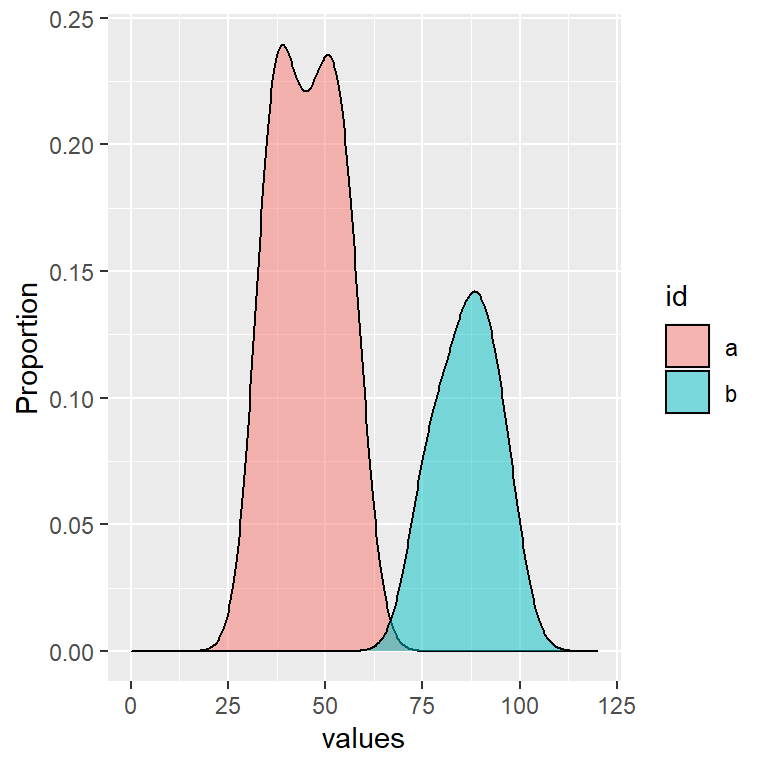

```r
#x = vector of grouping data in the original data entered into ggplot
#n = n from the geom_density() function, default is 512

#returns the proportion of all points belonging to each group
get.props <- function(x,n=512){
   rep(plyr::count(x)[,2]/sum(plyr::count(x)[,2]),each=n)}


ggplot(df,aes(x=values,fill=id))+
  geom_density(bw=5,alpha=0.5,color="black",aes(y=10*..density..*get.props(df$id)))+ #same as before except we have added the get.props function and are using it on the id column of the original data frame
  scale_x_continuous(limits=c(0,120))+
  labs(y="Proportion")
```

- You can prove to yourself that this worked by combing it with histograms (see section 7)

#### 6.1.2.1 Why this works

- This is just an extension of the solution we used for grouped density plots where each group sums to 1
- In that first solution, we calculated a density per group, each of which summed to 1
- If we want to convert that to a plot where all groups collectively sum to 1, we just have to scale each group by the proportion of points that belong to it
- That simply requires multiplying the density distribution per group by the proportion of points belonging to that group.
  - The get.props() function provides those proportions

### 6.1.3 Adding a mean line to a grouped density plot

- In some cases, you may want to add a mean line that shows the average value across all of your groups
- This **is not** as simple as just running geom_density without specifying groups because that will fail to take the differences in sample size into account
- The best solution I have been able to come up with is to:
  1. Make a simplified graph
  2. Extract the data from the graph using ggplot_build()
  3. Average those data
  4. Add them back into the graph using geom_line()
  - **NOTE** you must multiply the y values by the binwidth (see earlier code) in geom_line for this to plot correctly
- I have provided the function get.mean.density to simplify this
- First let’s make our starting graph
- I’m going to use a different data set to demonstrate this

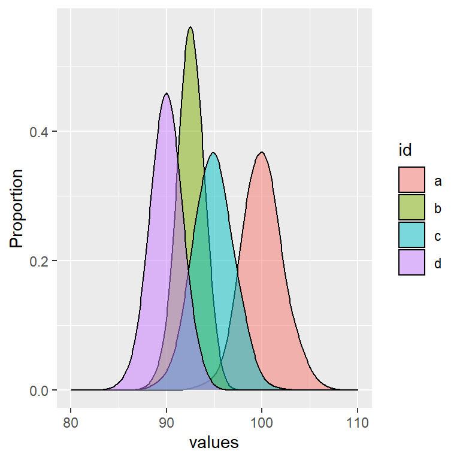

```r
set.seed(1234)
df2 <- cbind.data.frame(values=c(rnorm(300,100,2),rnorm(100,92.5,1),rnorm(400,95,2),rnorm(200,90,1.5)),id=c(rep("a",300),rep("b",100),rep("c",400),rep("d",200)))

p <- ggplot()+
  geom_density(df2,bw=1,alpha=0.5,color="black",mapping=aes(x=values,fill=id,y=2*..density..))+
  scale_x_continuous(limits=c(80,110))+
  labs(y="Proportion")

p
```

- Now we can use the function below to calculate the mean line (dplyr is required)

```r
# p = initial density plot (a gpplot object)
# n.groups = the number of groups in p
#n = n from geom_density, default is 512

get.mean.density <- function(p,n.groups,n=512){
  p.data <- as.data.frame(ggplot_build(p)$data) #extract data from graph
  p.data$bin <- rep(1:512,n.groups) #add a column of bin information based on n
  p.data.mean <- p.data %>% group_by(bin) %>% dplyr::summarize(x=x[1],y=mean(density)) #get averages
  p.data.mean}
```

- Run the function

```r
mean.density <- get.mean.density(p=p,n.groups=4)
```

- Add to plot as a line

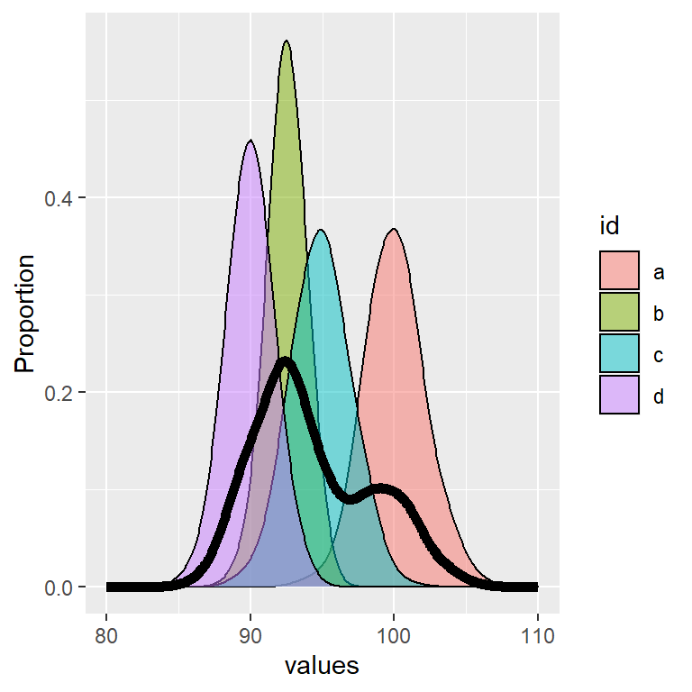

```r
ggplot()+
  geom_density(df2,bw=1,alpha=0.5,color="black",mapping=aes(x=values,fill=id,y=2*..density..))+ #binwidth = 2
  scale_x_continuous(limits=c(80,110))+
  labs(y="Proportion")+
  geom_line(mean.density,mapping=aes(x=x,y=2*y),size=2) #note that y is multiplied by 2 because that is the binwidth used above
```

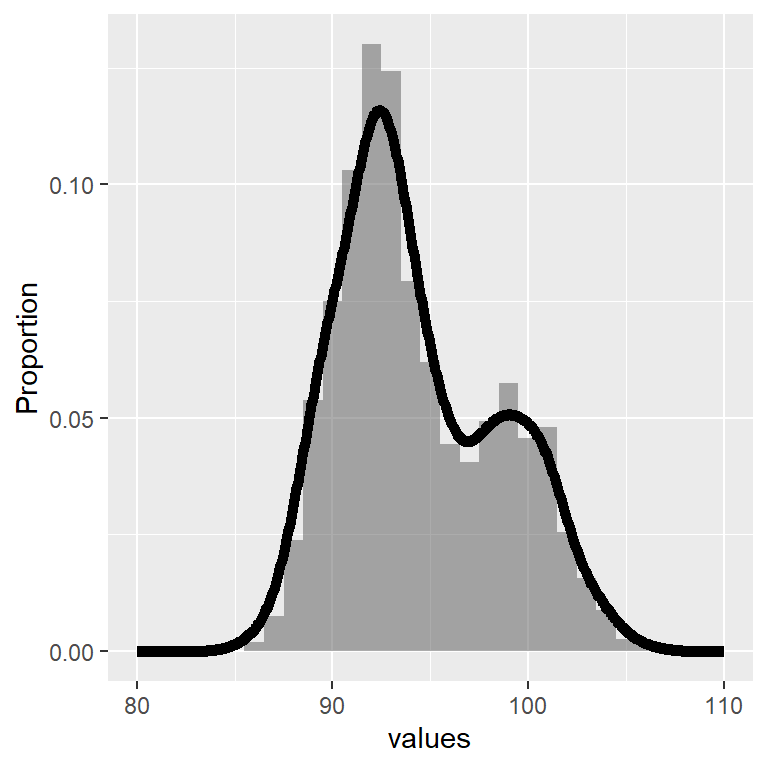

```r
# modify data so that sample sizes are the same per group
set.seed(1234)
df3 <- cbind.data.frame(values=c(rnorm(400,100,2),rnorm(400,92.5,1),rnorm(400,95,2),rnorm(400,90,1.5)),id=c(rep("a",400),rep("b",400),rep("c",400),rep("d",400)))

#make proportional histogram with those data (no groups specified) and include our mean line from before
ggplot()+
  geom_histogram(df3,binwidth=1,alpha=0.5,mapping=aes(x=values,y=stat(width*density)))+
  scale_x_continuous(limits=c(80,110))+
  labs(y="Proportion")+
  geom_line(mean.density,mapping=aes(x=x,y=y),size=2) #note that y does not need to be multiplied by anything because binwidth is 1
```

- Note that it is not a 100% perfect match, but that is to be expected from smoothed density lines compared to block histograms
- So far what I have shown seems pretty ugly and pointless, so let me try to give a nice illustration of the type of thing you can do with this
- If, for example, you have 8 largely overlapping groups, and you want to show the central tendency and the variation, you can easily do so by plotting each group as the same color with an alpha, and plotting the mean line as a different color (in this case, yellow)

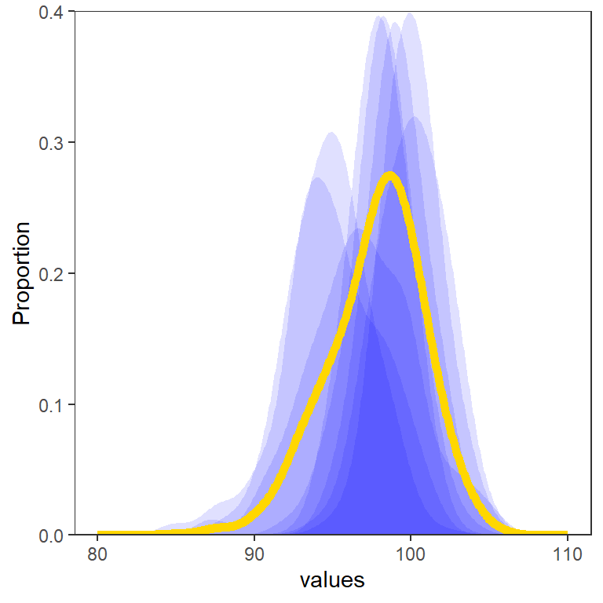

```r
#make data
set.seed(1234)
df4 <- cbind.data.frame(values=c(rnorm(300,100,1.8),rnorm(100,95,3),rnorm(400,95,2.5),rnorm(200,97,3.5),rnorm(300,100,2.3),rnorm(100,98,2.1),rnorm(400,98,1.75),rnorm(200,99,1.85)),id=c(rep("a",300),rep("b",100),rep("c",400),rep("d",200),rep("e",300),rep("f",100),rep("g",400),rep("h",200)))

#make initial plot
p2 <- ggplot()+
  geom_density(df4,bw=1,alpha=0.25,color="black",mapping=aes(x=values,fill=id,y=2*..density..))+
  scale_x_continuous(limits=c(80,110))

#get mean density values
mean.density2 <- get.mean.density(p=p2,n.groups=8)

#make final plot
ggplot()+
  geom_density(df4,bw=1,alpha=0.12,color=NA,mapping=aes(x=values,fill=id,y=2*..density..))+
  scale_x_continuous(limits=c(80,110))+
  scale_y_continuous(expand=c(0,0),limits=c(0,.4))+
  labs(y="Proportion")+
  geom_line(mean.density2,mapping=aes(x=x,y=2*y),size=2,color="gold")+
  scale_fill_manual(values=rep("blue",8))+
  theme_bw()+
  theme(panel.grid.major = element_blank(),panel.grid.minor=element_blank(),legend.position="none")
```

## 6.2 Things that don’t work

### 6.2.1 Default geom_density

- The default geom_density can be a bit misleading sometimes because it can give the appearance that things worked.
- As an example, let’s run the default, but divide our data by 10
- First lets try just running geom_density()

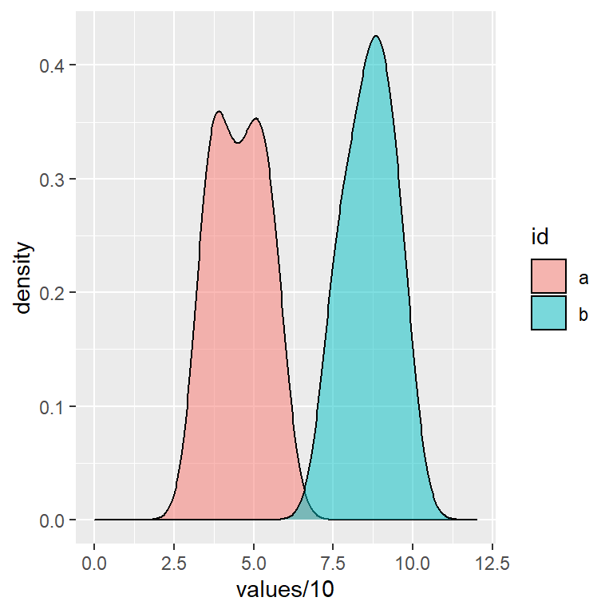

```r
ggplot(df,aes(x=values/10,fill=id))+
  geom_density(bw=.5,alpha=0.5,color="black")+
  scale_x_continuous(limits=c(0,12))
```

- That deceptively looks like it worked and we just need to rename the y axis, but it is an illusion. Or, more accurately, it worked on this particular data set, but will not work on a great many others.
- To illustrate, let’s run it on the original data without diving by 10

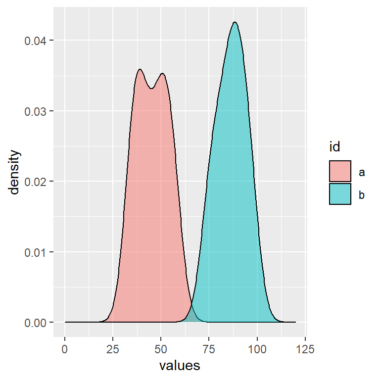

```r
ggplot(df,aes(x=values,fill=id))+
  geom_density(bw=5,alpha=0.5,color="black")+
  scale_x_continuous(limits=c(0,120))
```

- Notice that the shape of the curves has not changed (as expected from simply moving the decimal point).
- However, the y-axis no longer matches proportions and it is now difficult for mere mortals to interpret.
- This is because in both cases, the y is the kernel density; it just happens that in some cases that aligns with proportions, but that **is not** always the case. To ensure it matches proportions, we have to integrate over some length

### 6.2.2 ..scaled..

- I have frequently seen this proposed as a solution, but it **does not** do what we are after.
- It scales each group from 0-1, but that actually distorts the differences between groups and in no way helps with the interpretation

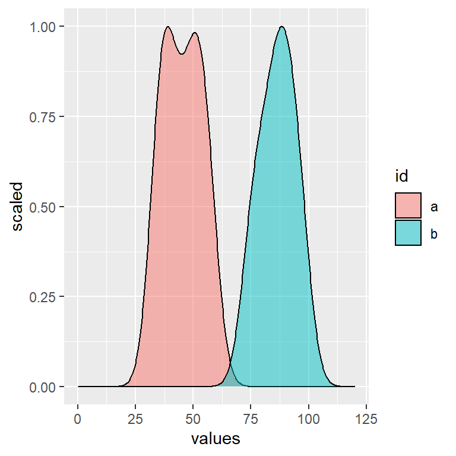

```r
ggplot(df,aes(x=values,fill=id))+
  geom_density(bw=5,alpha=0.5,color="black",aes(y=..scaled..))+
  scale_x_continuous(limits=c(0,120))
```

- As you can see, this makes the shape of “a” and “b” look more similar than they actually are, because *both* groups now scale from 0-1, even though the peak for “b” should actually be higher than the peak for “a”
- Further, the y axis still is not particularly helpful (if anything, it is even more confusing now, IMO, because the scaled values look like proportions at a quick glance, even though they clearly aren’t)

# 7 Combing histograms and density plots

- You may, in some cases, want that smoothed density line plotted over your histograms
- This is easy to do by simply combining the solutions for each plot type
- It is also a useful sanity check to make sure the density plots are doing what you expect

## 7.1 Combine plots where each group sums to 1

- Add the smoothed density lines over each histogram
  - Note that I have set boundary back to default to ensure that the plots line up

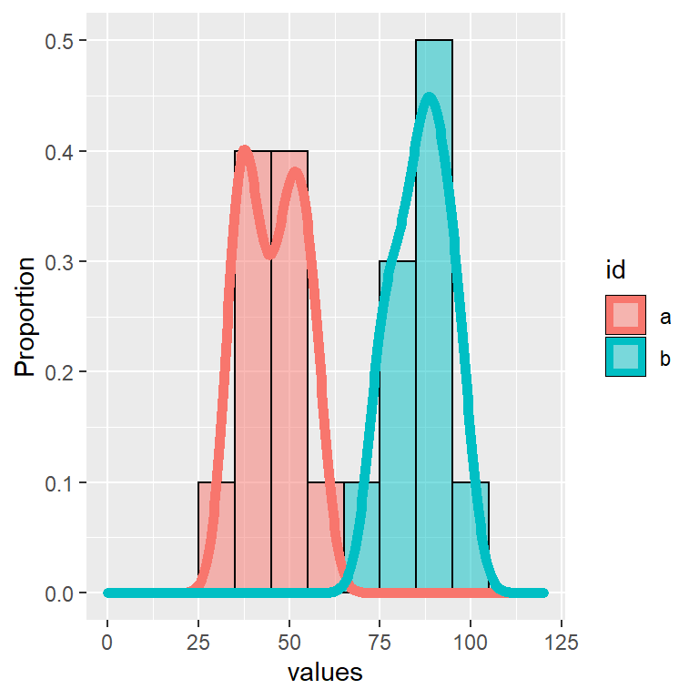

```r
ggplot(df,aes(x=values,fill=id))+
  #histogram portion
  geom_histogram(binwidth=10,alpha=0.5,color="black",mapping=aes(y=stat(width*density)))+
  geom_density(size=2,alpha=0,mapping=aes(y=10*..density..,color=id))+
  scale_x_continuous(limits=c(0,120))+
  labs(y="Proportion")
```

## 7.2 Combine plots where all data sums to 1

- Add the smoothed density lines over each histogram
  - Note that I have set boundary back to default to ensure that the plots line up

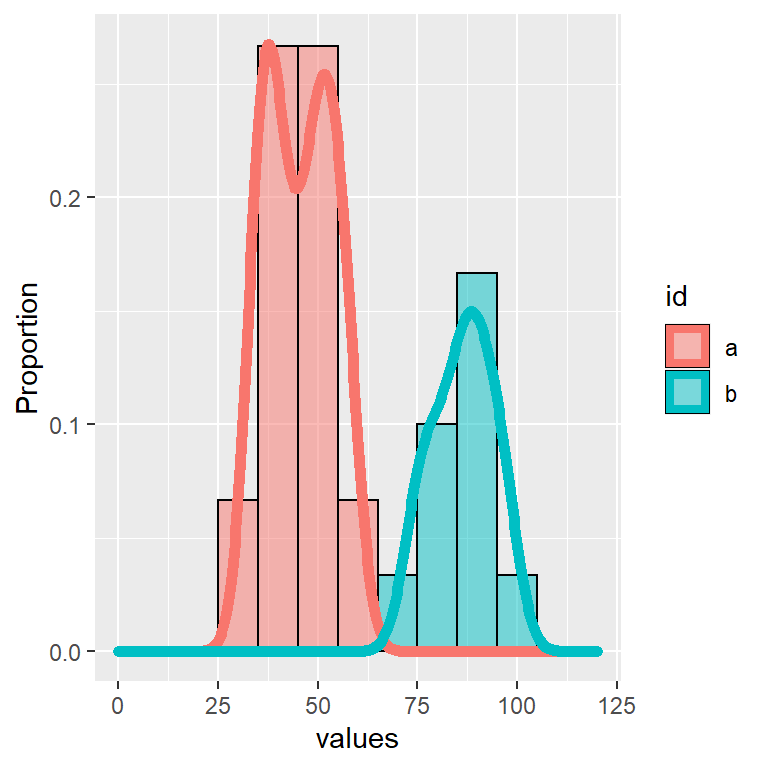

```r
ggplot(df,aes(x=values,fill=id))+
  #histogram portion
  geom_histogram(binwidth=10,alpha=0.5,color="black",mapping=aes(y=..count../sum(..count..)))+
  geom_density(size=2,alpha=0,mapping=aes(y=10*..density..*get.props(df$id),color=id))+
  scale_x_continuous(limits=c(0,120))+
  labs(y="Proportion")
```